# Homework5

21400022 YounhongKo

2020 6 5

## Read RData File

```r
load('hw5_student.RData')
```

## Declare Functions && Libraries

```r
library(ROCR)
calcRMSE <- function(label, estimation){
  return(sqrt(mean((label - estimation) ** 2)))
}
calcR2 <- function(label, estimation){
  RSS = sum((label - estimation) ** 2)
  SStot = sum((label - mean(label)) ** 2)
  return(1-RSS/SStot)
}
getRecall <- function(i) {
  conf.credit.train <- table(pred=credit_train$pred>i, actual=credit_train$default.payment.next.month)
  conf.credit.train[2,2]/sum(conf.credit.train[,2])
}
calAUC <- function(predCol, targetCol){
  perf <- performance(prediction(predCol, targetCol), 'auc')
  as.numeric(perf@y.values)
}
```

# Part 1 Linear Regression Model

## Question 1

```r
student_model <- lm(G3 ~ ., student.train)
student_model
```

```
##
## Call:
## lm(formula = G3 ~ ., data = student.train)
##
## Coefficients:
##      (Intercept)          schoolMS              sexM               age
##         8.704996         -0.930515          0.010702         -0.011660
##         addressU        famsizeLE3          PstatusT              Medu
##         0.198465          0.638627          0.193760          0.283115
##             Fedu        Mjobhealth         Mjobother      Mjobservices
##         0.022797          1.010029          0.062953          0.398141
##      Mjobteacher        Fjobhealth         Fjobother      Fjobservices
##        -0.324385         -0.163307         -0.160301         -0.405666
##      Fjobteacher        reasonhome       reasonother  reasonreputation
##         1.237797         -0.255527         -0.213131          0.052072
##   guardianmother     guardianother        traveltime         studytime
##        -0.339065          0.140611         -0.094225          0.521214
##         failures      schoolsupyes         famsupyes           paidyes
##        -1.528736         -1.186957         -0.452729          0.277973
##    activitiesyes        nurseryyes         higheryes       internetyes
##        -0.009756         -0.117956          1.511059          0.397765
##      romanticyes            famrel          freetime             goout
##        -0.588509          0.151968          0.033525         -0.281884
##             Dalc              Walc            health          absences
##        -0.136858          0.077130         -0.200628          0.022961
##        classport
##         2.088339
```

```r
summary(student_model)
```

```
##
## Call:
## lm(formula = G3 ~ ., data = student.train)
##
## Residuals:
##      Min       1Q   Median       3Q      Max
## -12.5592  -1.4544   0.1795   1.9035   7.4596
##
## Coefficients:
##                   Estimate Std. Error t value Pr(>|t|)
## (Intercept)       8.704996   2.210876   3.937 8.94e-05 ***
## schoolMS         -0.930515   0.323840  -2.873 0.004166 **
## sexM              0.010702   0.268735   0.040 0.968245
## age              -0.011660   0.110558  -0.105 0.916031
## addressU          0.198465   0.292729   0.678 0.497974
## famsizeLE3        0.638627   0.270929   2.357 0.018649 *
## PstatusT          0.193760   0.378551   0.512 0.608896
## Medu              0.283115   0.167588   1.689 0.091533 .
## Fedu              0.022797   0.147379   0.155 0.877107
## Mjobhealth        1.010029   0.596285   1.694 0.090670 .
## Mjobother         0.062953   0.342337   0.184 0.854143
## Mjobservices      0.398141   0.416942   0.955 0.339906
## Mjobteacher      -0.324385   0.556909  -0.582 0.560407
## Fjobhealth       -0.163307   0.808664  -0.202 0.840009
## Fjobother        -0.160301   0.514500  -0.312 0.755449
## Fjobservices     -0.405666   0.540709  -0.750 0.453320
## Fjobteacher       1.237797   0.716084   1.729 0.084264 .
## reasonhome       -0.255527   0.306016  -0.835 0.403953
## reasonother      -0.213131   0.413736  -0.515 0.606596
## reasonreputation  0.052072   0.318089   0.164 0.870007
## guardianmother   -0.339065   0.289775  -1.170 0.242301
## guardianother     0.140611   0.562826   0.250 0.802781
## traveltime       -0.094225   0.176476  -0.534 0.593538
## studytime         0.521214   0.154007   3.384 0.000747 ***
## failures         -1.528736   0.194962  -7.841 1.39e-14 ***
## schoolsupyes     -1.186957   0.373757  -3.176 0.001550 **
## famsupyes        -0.452729   0.251574  -1.800 0.072294 .
## paidyes           0.277973   0.340677   0.816 0.414769
## activitiesyes    -0.009756   0.240451  -0.041 0.967646
## nurseryyes       -0.117956   0.292021  -0.404 0.686370
## higheryes         1.511059   0.442193   3.417 0.000664 ***
## internetyes       0.397765   0.306981   1.296 0.195432
## romanticyes      -0.588509   0.253639  -2.320 0.020571 *
## famrel            0.151968   0.128009   1.187 0.235506
## freetime          0.033525   0.124703   0.269 0.788124
## goout            -0.281884   0.117098  -2.407 0.016293 *
## Dalc             -0.136858   0.171898  -0.796 0.426170
## Walc              0.077130   0.130255   0.592 0.553918
## health           -0.200628   0.084200  -2.383 0.017411 *
## absences          0.022961   0.019216   1.195 0.232488
## classport         2.088339   0.280745   7.439 2.57e-13 ***
## ---
## Signif. codes:  0 '***' 0.001 '**' 0.01 '*' 0.05 '.' 0.1 ' ' 1
##
## Residual standard error: 3.331 on 820 degrees of freedom
## Multiple R-squared:  0.2954, Adjusted R-squared:  0.261
## F-statistic: 8.593 on 40 and 820 DF,  p-value: < 2.2e-16
```

## Question 2

```r
student.train$pred <- predict(student_model, newdata = student.train)
student.test.nolabel$pred <- predict(student_model, newdata = student.test.nolabel)
calcRMSE(student.train$G3, student.train$pred)
```

```
## [1] 3.250976
```

```r
calcR2(student.train$G3, student.train$pred)
```

```
## [1] 0.2953602
```

> > RMSE for train: 3.25, R2 for train: 0.295  
> > RMSE for test: 3.42, R2 for test: 0.179

## Question 3

> > Variables that affect Final Grade has high value of coeffient value for model. And as you can see from summary(student_model), they are marked with * next to p value.

> > Variables that affect Negatively: failures, schoolyes, schoolMS

> > Variables that affect Positively: classport higheryes, famsizeLE3, studytime

## Question 4

```r
student_model <- lm(G3 ~ . + I(studytime^2)+I(health^2), student.train)
student.train$pred <- predict(student_model, newdata = student.train)
calcRMSE(student.train$G3, student.train$pred)
```

```
## [1] 3.248528
```

```r
calcR2(student.train$G3, student.train$pred)
```

```
## [1] 0.2964209
```

## Question 5

```r
student_model <- lm(G3 ~ school + address + famsize + Pstatus + Medu + Fedu + Mjob + Fjob + reason
                    + guardian + traveltime + studytime + failures + schoolsup + famsup + paid + nursery
                    + higher + internet + romantic + famrel + freetime + goout + Dalc + Walc + health
                    + absences + class, student.train)

student.train$pred <- predict(student_model, newdata = student.train)

calcRMSE(student.train$G3, student.train$pred)
```

```
## [1] 3.251003
```

```r
calcR2(student.train$G3, student.train$pred)
```

```
## [1] 0.2953483
```

> > Since activities, age, sex has low coefficients values, it does not have much effect on grade. After we delete those variables from model, we can find that RMSE has increased by little and R2 has decreased by little which means performance has been less accurate and downgraded.

## Question 6

```r
student_model <- lm(G3 ~ . + I(studytime^2)+I(health^2), student.train)
student.train$pred <- predict(student_model, newdata = student.train)
student.test.nolabel$pred <- predict(student_model, newdata = student.test.nolabel)
pred_grade_test <- student.test.nolabel$pred
save(pred_grade_test, file="st21400022.RData")
```

> > RMSE: 3.42, R2: 0.178

# Part 2 - Logistic Regression Model

## Question 1

```r
fmla <- "default.payment.next.month~."
credit_model <- glm(fmla, data=credit_train, family = binomial(link='logit'))
credit_model
```

```
##
## Call:  glm(formula = fmla, family = binomial(link = "logit"), data = credit_train)
##
## Coefficients:
## (Intercept)    LIMIT_BAL          SEX    EDUCATION     MARRIAGE
##  -6.789e-01   -7.621e-07   -1.047e-01   -1.211e-01   -1.533e-01
##         AGE        PAY_1        PAY_2        PAY_3        PAY_4
##   8.176e-03    5.700e-01    9.064e-02    6.079e-02    4.025e-02
##       PAY_5        PAY_6    BILL_AMT1    BILL_AMT2    BILL_AMT3
##   3.109e-02    4.448e-03   -4.361e-06    5.831e-07    2.109e-06
##   BILL_AMT4    BILL_AMT5    BILL_AMT6     PAY_AMT1     PAY_AMT2
##  -2.175e-07    5.699e-07    2.481e-07   -9.927e-06   -1.419e-05
##    PAY_AMT3     PAY_AMT4     PAY_AMT5     PAY_AMT6
##  -2.153e-06   -5.274e-06   -2.933e-06   -1.393e-06
##
## Degrees of Freedom: 24999 Total (i.e. Null);  24976 Residual
## Null Deviance:       26450
## Residual Deviance: 23230     AIC: 23280
```

```r
summary(credit_model)
```

```
##
## Call:
## glm(formula = fmla, family = binomial(link = "logit"), data = credit_train)
##
## Deviance Residuals:
##     Min       1Q   Median       3Q      Max
## -3.0996  -0.6991  -0.5483  -0.2911   3.5930
##
## Coefficients:
##               Estimate Std. Error z value Pr(>|z|)
## (Intercept) -6.789e-01  1.295e-01  -5.244 1.57e-07 ***
## LIMIT_BAL   -7.621e-07  1.725e-07  -4.418 9.95e-06 ***
## SEX         -1.047e-01  3.361e-02  -3.117 0.001827 **
## EDUCATION   -1.211e-01  2.301e-02  -5.260 1.44e-07 ***
## MARRIAGE    -1.533e-01  3.467e-02  -4.422 9.77e-06 ***
## AGE          8.176e-03  1.945e-03   4.204 2.62e-05 ***
## PAY_1        5.700e-01  1.938e-02  29.403  < 2e-16 ***
## PAY_2        9.064e-02  2.214e-02   4.095 4.22e-05 ***
## PAY_3        6.079e-02  2.486e-02   2.445 0.014468 *
## PAY_4        4.025e-02  2.747e-02   1.465 0.142889
## PAY_5        3.109e-02  2.954e-02   1.052 0.292604
## PAY_6        4.448e-03  2.434e-02   0.183 0.854979
## BILL_AMT1   -4.361e-06  1.207e-06  -3.614 0.000302 ***
## BILL_AMT2    5.831e-07  1.656e-06   0.352 0.724688
## BILL_AMT3    2.109e-06  1.460e-06   1.444 0.148730
## BILL_AMT4   -2.175e-07  1.475e-06  -0.147 0.882766
## BILL_AMT5    5.699e-07  1.668e-06   0.342 0.732610
## BILL_AMT6    2.481e-07  1.309e-06   0.190 0.849679
## PAY_AMT1    -9.927e-06  2.308e-06  -4.301 1.70e-05 ***
## PAY_AMT2    -1.419e-05  2.637e-06  -5.383 7.32e-08 ***
## PAY_AMT3    -2.153e-06  1.837e-06  -1.172 0.241280
## PAY_AMT4    -5.274e-06  2.060e-06  -2.561 0.010445 *
## PAY_AMT5    -2.933e-06  1.917e-06  -1.530 0.126059
## PAY_AMT6    -1.393e-06  1.386e-06  -1.005 0.314980
## ---
## Signif. codes:  0 '***' 0.001 '**' 0.01 '*' 0.05 '.' 0.1 ' ' 1
##
## (Dispersion parameter for binomial family taken to be 1)
##
##     Null deviance: 26446  on 24999  degrees of freedom
## Residual deviance: 23232  on 24976  degrees of freedom
## AIC: 23280
##
## Number of Fisher Scoring iterations: 6
```

```r
coefficients(credit_model)
```

```
##   (Intercept)     LIMIT_BAL           SEX     EDUCATION      MARRIAGE
## -6.788620e-01 -7.621217e-07 -1.047465e-01 -1.210569e-01 -1.533011e-01
##           AGE         PAY_1         PAY_2         PAY_3         PAY_4
##  8.175583e-03  5.699634e-01  9.064326e-02  6.079013e-02  4.024680e-02
##         PAY_5         PAY_6     BILL_AMT1     BILL_AMT2     BILL_AMT3
##  3.108883e-02  4.447786e-03 -4.361449e-06  5.830858e-07  2.108773e-06
##     BILL_AMT4     BILL_AMT5     BILL_AMT6      PAY_AMT1      PAY_AMT2
## -2.175264e-07  5.698873e-07  2.480528e-07 -9.926935e-06 -1.419474e-05
##      PAY_AMT3      PAY_AMT4      PAY_AMT5      PAY_AMT6
## -2.152935e-06 -5.274420e-06 -2.933277e-06 -1.393175e-06
```

```r
credit_train$pred <- predict(credit_model, newdata = credit_train, type="response")
credit_test$pred <- predict(credit_model, newdata = credit_test, type="response")
```

## Question 2

```r
calAUC(credit_train$pred, credit_train$default.payment.next.month)
```

```
## [1] 0.7245918
```

> > 0.724

## Question 3

```r
threshold <- 0.5

conf.credit.train <- table(pred=credit_train$pred>threshold, actual=credit_train$default.payment.next.month)
credit_train_prec <- conf.credit.train[2,2]/sum(conf.credit.train[2,])
credit_train_prec
```

```
## [1] 0.7172996
```

```r
credit_train_rec <- conf.credit.train[2,2]/sum(conf.credit.train[,2])
credit_train_rec
```

```
## [1] 0.2454874
```

```r
credit_train_acc <- sum(diag(conf.credit.train)) / sum(conf.credit.train)
credit_train_acc
```

```
## [1] 0.81136
```

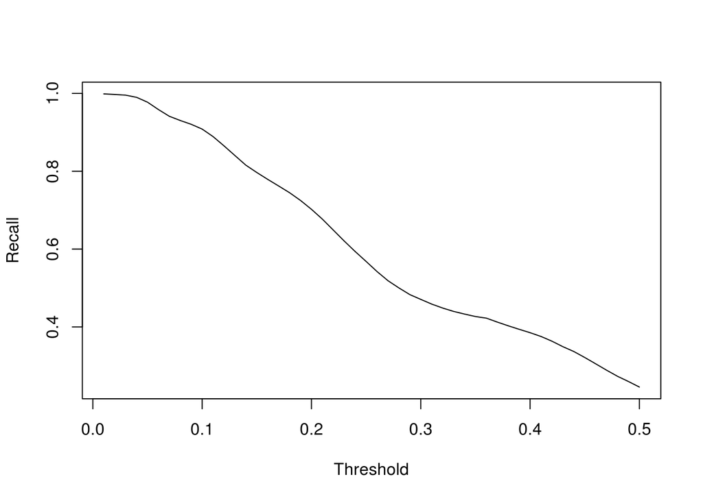

```r
thres_list <- seq(0.01, 0.50, 0.01)
rec_list <- sapply(thres_list, getRecall)
plot(x=thres_list, rec_list, xlab="Threshold", ylab="Recall", type="l")
```

> > In this model, recall costs more than precision so false positive costs more than false negative. So, to increase recall you can try adjusting threshold value. If you lower threshold, you get higher value of recall.

```r
thres_list <- 0.01

conf.credit.train <- table(pred=credit_train$pred>threshold, actual=credit_train$default.payment.next.month)
credit_train_prec <- conf.credit.train[2,2]/sum(conf.credit.train[2,])
credit_train_prec
```

```
## [1] 0.7172996
```

```r
credit_train_rec <- conf.credit.train[2,2]/sum(conf.credit.train[,2])
credit_train_rec
```

```
## [1] 0.2454874
```

```r
credit_train_acc <- sum(diag(conf.credit.train)) / sum(conf.credit.train)
credit_train_acc
```

```
## [1] 0.81136
```

## Question 4

```r
fmla <- "default.payment.next.month~.+I(AGE^2)+I(EDUCATION^2)+I(MARRIAGE^2)+I(PAY_AMT2^2)+I(PAY_AMT3^2)"
credit_model <- glm(fmla, data=credit_train, family = binomial(link='logit'))

credit_train$pred <- predict(credit_model, newdata = credit_train, type="response")
credit_test$pred <- predict(credit_model, newdata = credit_test, type="response")

calAUC(credit_train$pred, credit_train$default.payment.next.month)
```

```
## [1] 0.7365724
```

```r
conf.credit.train <- table(pred=credit_train$pred>threshold, actual=credit_train$default.payment.next.month)
credit_train_prec <- conf.credit.train[2,2]/sum(conf.credit.train[2,])
credit_train_prec
```

```
## [1] 0.6879655
```

```r
credit_train_rec <- conf.credit.train[2,2]/sum(conf.credit.train[,2])
credit_train_rec
```

```
## [1] 0.316787
```

```r
credit_train_acc <- sum(diag(conf.credit.train)) / sum(conf.credit.train)
credit_train_acc
```

```
## [1] 0.81676
```

> > AUC for test data(from website): 0.729

## Question 5

```r
prob_default_test <- credit_test$pred
pred_default_test <- credit_test$pred > threshold
save(prob_default_test, pred_grade_test, pred_default_test, file="st21400022.RData")
```

> > Accuracy: 0.815, Precision: 0.691, Recall: 0.279